# R Notebook

```
source("R/common.R", local = knitr::knit_global())
library(ggplot2)
library(ggalluvial)
library(mclust)
```

# Data Prep

```
insect_plant_cluster_json = read_input_json(INSECT_PLANT_CLUSTERS)
```

```
bird_cluster_json = read_input_json(BIRD_CLUSTERS)
```

```
row_to_df = function(x) {
  tibble(
    cluster_id = as.integer(x$cluster_id),
    cluster_name = x$cluster_name,
    cluster_description = x$cluster_description,
    habitat_description_from_photos = x$habitat_description_from_photos,
    representative_plot_image = x$representative_plot_image
  )
}

bird_clusters = map_dfr(bird_cluster_json, row_to_df) %>% dplyr::select(cluster_id, cluster_name)
insect_plant_clusters = map_dfr(insect_plant_cluster_json, row_to_df) %>% dplyr::select(cluster_id, cluster_name)
insect_plant_clusters
```

| cluster_id | cluster_name |
| --- | --- |
| 7 | short turf / intensively managed lawn |
| 5 | mature large-tree canopy / woodland |
| 3 | amenity grassland / meadow |
| 4 | parkland — mature trees over grass |
| 2 | mixed multi-layer woodland |
| 1 | built-dominated urban with vegetated fragments |
| 8 | shrub–small-tree mosaic / young scrub-woodland |
| 6 | impervious / hard-standing |
| 0 | grass with scattered trees (residential/greenspace) |

```
plots_in_cluster = function(cluster_json, cluster_id) {
  idx = which(sapply(cluster_json, function(x) x$cluster_id) == cluster_id)
  if (length(idx) == 0) return(NULL)

  df = data.frame(plot_id = cluster_json[[idx]]['plots'])
  df$cluster_id = cluster_id
  df
}

plots_in_cluster_insect_plants = function(cluster_id) plots_in_cluster(insect_plant_cluster_json, cluster_id)
plots_in_cluster_birds = function(cluster_id) plots_in_cluster(bird_cluster_json, cluster_id)

plots_in_cluster_insect_plants(8)
```

| plots | cluster_id |
| --- | --- |
| 1020 11 | 8 |
| 1020 4 | 8 |
| 108 4 | 8 |
| 112 5 | 8 |
| 145 7 | 8 |
| 202 2 | 8 |
| 231 1 | 8 |
| 231 12 | 8 |
| 237 9 | 8 |
| 248 2 | 8 |

[output cut: 37 more lines]

```
insect_plants_plots = map_dfr(0:9, plots_in_cluster_insect_plants) %>% left_join(insect_plant_clusters, by = 'cluster_id') %>% rename('plot_id' = plots)
insect_plants_plots
```

| plot_id | cluster_id | cluster_name |
| --- | --- | --- |
| 1084 3 | 0 | grass with scattered trees (residential/greenspace) |
| 136 7 | 0 | grass with scattered trees (residential/greenspace) |
| 202 8 | 0 | grass with scattered trees (residential/greenspace) |
| 298 6 | 0 | grass with scattered trees (residential/greenspace) |
| 300 4 | 0 | grass with scattered trees (residential/greenspace) |
| 311 6 | 0 | grass with scattered trees (residential/greenspace) |
| 335 9 | 0 | grass with scattered trees (residential/greenspace) |
| 369 1 | 0 | grass with scattered trees (residential/greenspace) |
| 389 2 | 0 | grass with scattered trees (residential/greenspace) |
| 393 1 | 0 | grass with scattered trees (residential/greenspace) |

[output cut: 401 more lines]

```
bird_plots = map_dfr(0:9, plots_in_cluster_birds) %>% left_join(bird_clusters, by = 'cluster_id') %>% rename('plot_id' = plots)
bird_plots
```

| plot_id | cluster_id | cluster_name |
| --- | --- | --- |
| 1007 6 | 0 | built-dominated urban with vegetated fragments |
| 1083 2 | 0 | built-dominated urban with vegetated fragments |
| 1084 6 | 0 | built-dominated urban with vegetated fragments |
| 1084 7 | 0 | built-dominated urban with vegetated fragments |
| 112 5 | 0 | built-dominated urban with vegetated fragments |
| 233 11 | 0 | built-dominated urban with vegetated fragments |
| 239 11 | 0 | built-dominated urban with vegetated fragments |
| 298 11 | 0 | built-dominated urban with vegetated fragments |
| 335 1 | 0 | built-dominated urban with vegetated fragments |
| 335 7 | 0 | built-dominated urban with vegetated fragments |

[output cut: 401 more lines]

Order clusters by NDVI

```
bird_clusters = bird_plots %>%
  left_join(read_input_csv(BIRD_PREDICTORS) %>% to_ndvi()) %>%
  group_by(cluster_name) %>%
  summarise(avg_ndvi = mean(ndvi)) %>%
  left_join(bird_clusters) %>%
  arrange(avg_ndvi)
```

```
bird_clusters
```

| cluster_name | avg_ndvi | cluster_id |
| --- | --- | --- |
| impervious / hard-standing | 0.2685714 | 6 |
| built-dominated urban with vegetated fragments | 0.4233333 | 0 |
| grass with scattered trees (residential/greenspace) | 0.5356522 | 8 |
| shrub–small-tree mosaic / young scrub-woodland | 0.6092308 | 2 |
| parkland — scattered trees over grass | 0.7019672 | 5 |
| amenity grassland / meadow | 0.7596721 | 7 |
| short turf / intensively managed lawn | 0.7906250 | 4 |
| parkland — mature trees over grass | 0.8000000 | 1 |
| mature large-tree canopy / woodland | 0.8600000 | 3 |

```
insect_plant_clusters = insect_plants_plots %>%
  left_join(read_input_csv(INSECT_PLANT_PREDICTORS) %>% to_ndvi()) %>%
  group_by(cluster_name) %>%
  summarise(avg_ndvi = mean(ndvi)) %>%
  left_join(insect_plant_clusters) %>%
  arrange(avg_ndvi)
```

```
insect_plant_clusters
```

| cluster_name | avg_ndvi | cluster_id |
| --- | --- | --- |
| impervious / hard-standing | 0.2950000 | 6 |
| built-dominated urban with vegetated fragments | 0.4805000 | 1 |
| grass with scattered trees (residential/greenspace) | 0.6997500 | 0 |
| short turf / intensively managed lawn | 0.7167500 | 7 |
| shrub–small-tree mosaic / young scrub-woodland | 0.7885106 | 8 |
| amenity grassland / meadow | 0.7968421 | 3 |
| parkland — mature trees over grass | 0.8047368 | 4 |
| mixed multi-layer woodland | 0.8190000 | 2 |
| mature large-tree canopy / woodland | 0.8445455 | 5 |

```
plots = insect_plants_plots %>% left_join(insect_plant_clusters) %>% rename('insect_plants_cluster_name' = cluster_name, 'insect_plants_ndvi' = avg_ndvi) %>%
  dplyr::select(plot_id, insect_plants_cluster_name, insect_plants_ndvi) %>%
  left_join(bird_plots %>% left_join(bird_clusters) %>% rename('birds_cluster_name' = cluster_name, 'birds_ndvi' = avg_ndvi) %>% dplyr::select(plot_id, birds_cluster_name, birds_ndvi)) %>%
  arrange(insect_plants_ndvi, birds_ndvi) %>%
  dplyr::select(plot_id, insect_plants_cluster_name, birds_cluster_name)
```

```
plots
```

| plot_id | insect_plants_cluster_name | birds_cluster_name |
| --- | --- | --- |
| 1084 12 | impervious / hard-standing | impervious / hard-standing |
| 202 6 | impervious / hard-standing | impervious / hard-standing |
| 239 1 | impervious / hard-standing | impervious / hard-standing |
| 239 3 | impervious / hard-standing | impervious / hard-standing |
| 239 5 | impervious / hard-standing | impervious / hard-standing |
| 242 2 | impervious / hard-standing | impervious / hard-standing |
| 336 2 | impervious / hard-standing | impervious / hard-standing |
| 369 12 | impervious / hard-standing | impervious / hard-standing |
| 369 3 | impervious / hard-standing | impervious / hard-standing |
| 369 8 | impervious / hard-standing | impervious / hard-standing |

[output cut: 401 more lines]

# Plots

```
# Long format for ggalluvial
plots_long =
  plots %>%
  pivot_longer(
    cols = c(insect_plants_cluster_name, birds_cluster_name),
    names_to = "scale",
    values_to = "cluster"
  ) %>%
  mutate(
    # order left–right
    scale = factor(scale,
                   levels = c("insect_plants_cluster_name", "birds_cluster_name"),
                   labels = c("20 x 20 m Cluster", "120 x 120 m Cluster")),
    # make sure cluster order is consistent and not alphabetical chaos
    cluster = factor(cluster)
  )

ggplot(
  plots_long,
  aes(
    x = scale,
    stratum = cluster,
    alluvium = plot_id,   # one flow per plot
    y = 1
  )
) +
  geom_flow(
    stat = "alluvium",
    lode.guidance = "forward",
    alpha = 0.3
  ) +
  geom_stratum(width = 0.4) +
  geom_text(
    stat = "stratum",
    aes(label = cluster),
    size = 3
  ) +
  scale_x_discrete(expand = c(0.2, 0.2)) +
  labs(
    x = NULL,
    y = "Number of plots",
    title = "Movement of plots between clusterings"
  ) +
  theme_minimal()
```

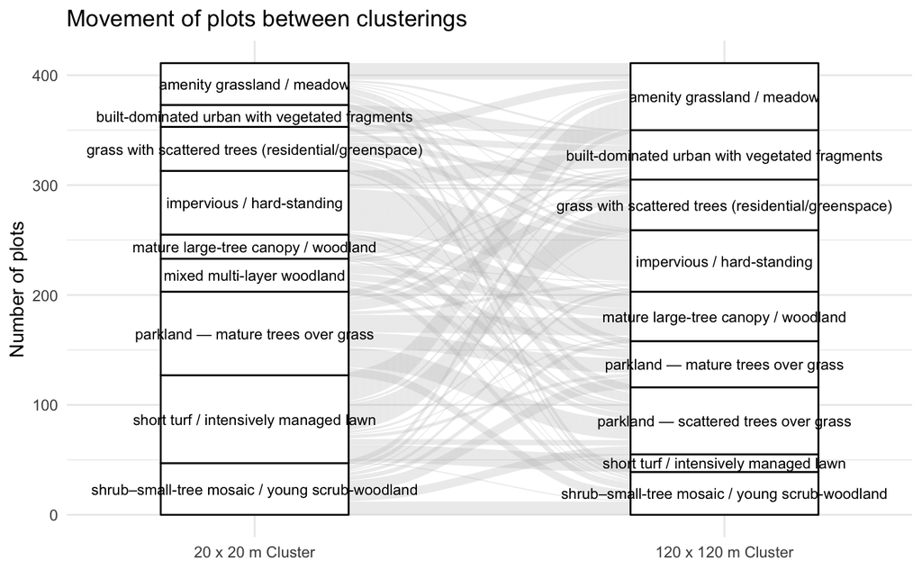

```
# Count how many plots move from each cluster pair
flows =
  plots %>%
    dplyr::count(insect_plants_cluster_name, birds_cluster_name, name = "n") %>%
    left_join(insect_plant_clusters %>% dplyr::select(cluster_name, avg_ndvi) %>% rename('insect_ndvi' = avg_ndvi, 'insect_plants_cluster_name' = cluster_name)) %>%
    left_join(bird_clusters %>% dplyr::select(cluster_name, avg_ndvi) %>% rename('bird_ndvi' = avg_ndvi, 'birds_cluster_name' = cluster_name)) %>%
    arrange(insect_ndvi, bird_ndvi) %>%
    mutate(
      # left axis ordered by insect_ndvi
      insect_plants_cluster_name =
        fct_reorder(insect_plants_cluster_name, insect_ndvi),

      # right axis ordered by bird_ndvi
      birds_cluster_name =
        fct_reorder(birds_cluster_name, bird_ndvi)
    )
```

```
ggplot(flows,
       aes(
         axis1 = insect_plants_cluster_name,
         axis2 = birds_cluster_name,
         y = n
       )) +
  geom_alluvium(aes(fill = insect_plants_cluster_name),
                width = 0, alpha = 0.5) +
  geom_stratum(width = 0.5) +
  geom_text(stat = "stratum", aes(label = after_stat(stratum)), size = 2) +
  scale_x_discrete(
    limits = c("20 x 20 m Cluster", "120 x 120 m Cluster"),
    expand = c(0.05, 0.05)
  ) +
  labs(
    x = NULL,
    y = "Number of plots",
    title = "Cluster transitions (aggregated by cluster pair)",
    fill = "20 x 20 m Cluster"
  ) +
  theme_minimal() +
  fill_scale(append_insect_plant_palette(insect_plant_clusters)) +
  theme(legend.position = "bottom", legend.text = element_text(size = 5)) +
  guides(fill = guide_legend(nrow = 3, byrow = TRUE))
ggsave('output/figure_2_plot_movement_between_clusters.jpg', width = 2500, height = 1000, units = 'px')
```

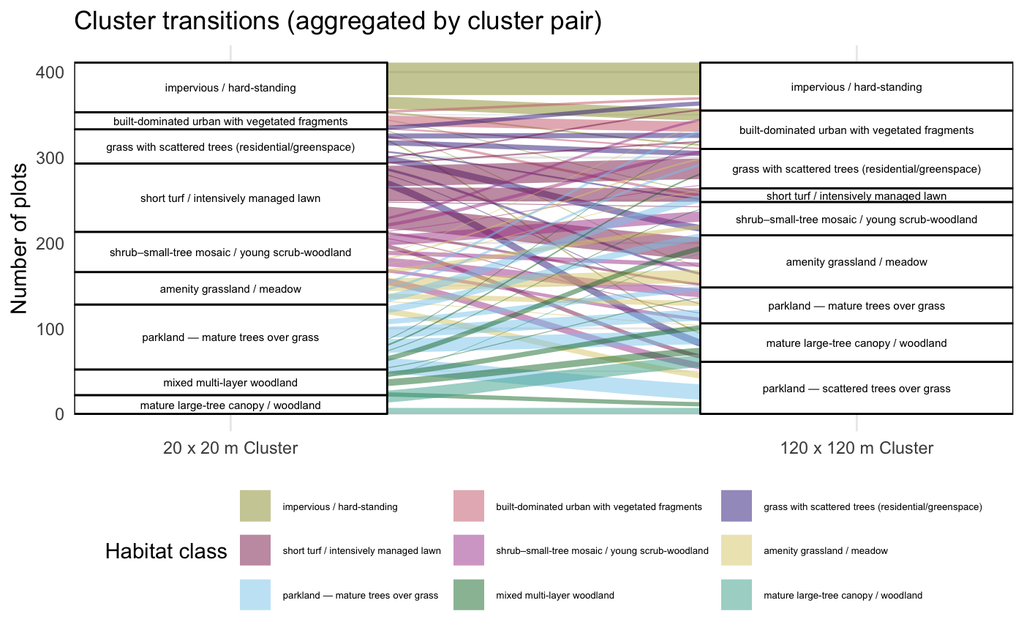

# Cluster Stability

## Global: how similar are the two partitions? (Adjusted Rand index + permutation test)

Use Adjusted Rand Index (ARI) as an overall measure of “same clustering”, then test if it’s greater than expected by chance.

```
ari_obs = adjustedRandIndex(plots$insect_plants_cluster_name, plots$birds_cluster_name)
ari_obs
```

```
[1] 0.1454845
```

ari_obs near 1 → very similar clusterings, near 0 → no more similar than random.

```
set.seed(1)
n_perm = 9999
ari_null = numeric(n_perm)

for (i in seq_len(n_perm)) {
  ari_null[i] = adjustedRandIndex(plots$insect_plants_cluster_name, sample(plots$birds_cluster_name))
}

p_val = mean(ari_null >= ari_obs)
p_val
```

```
[1] 0
```

## Flow matrix + χ² test + “who gains/loses?” via residuals

Build the contingency table of flows from 20x20 → 120x120 and analyse it.

```
flow_table =
  plots %>%
  dplyr::count(insect_plants_cluster_name, birds_cluster_name) %>%
  tidyr::pivot_wider(
    names_from = birds_cluster_name,
    values_from = n,
    values_fill = 0
  )

flow_mat = as.matrix(flow_table[ , -1])
rownames(flow_mat) = flow_table$insect_plants_cluster_name

# Chi-squared test of independence
chi_res = chisq.test(flow_mat)
```

```
chi_res$statistic   # overall X^2
```

```
X-squared
 529.3215
```

```
chi_res$p.value     # p-value
```

```
[1] 2.002178e-74
```

The real magic is in the standardised residuals:

```
resid_mat = chi_res$stdres  # same dimensions as flow_mat
resid_mat
```

```
                                                    amenity grassland / meadow built-dominated urban with vegetated fragments
amenity grassland / meadow                                           4.4833015                                     -1.1782593
built-dominated urban with vegetated fragments                      -1.9141608                                      7.2026325
grass with scattered trees (residential/greenspace)                  0.9658304                                      0.8636373
impervious / hard-standing                                          -3.4306661                                      3.4710055
mature large-tree canopy / woodland                                 -2.0127431                                     -1.6905311
mixed multi-layer woodland                                          -1.8415404                                     -0.7801622
parkland — mature trees over grass                                  -1.8869157                                     -2.1651784
short turf / intensively managed lawn                                4.9503968                                     -2.6967914
shrub–small-tree mosaic / young scrub-woodland                      -0.8613475                                     -0.5688469
                                                    grass with scattered trees (residential/greenspace) impervious / hard-standing mature large-tree canopy / woodland
amenity grassland / meadow                                                                   -1.7570364                 -2.0736564                          -1.7236022
built-dominated urban with vegetated fragments                                               -0.1733877                  0.1837333                          -1.6077305
grass with scattered trees (residential/greenspace)                                           0.8039943                 -0.2183572                          -1.8011895
impervious / hard-standing                                                                   -2.0184868                 12.4302846                          -2.8814645
mature large-tree canopy / woodland                                                          -1.7115514                 -1.9148611                           8.1350406
mixed multi-layer woodland                                                                   -1.4180653                 -1.7066766                           2.8635500
parkland — mature trees over grass                                                            0.1990501                 -2.7240914                           3.1245099
short turf / intensively managed lawn                                                         5.9457419                 -3.2321941                          -3.0957768
shrub–small-tree mosaic / young scrub-woodland                                               -2.0945083                 -1.5379096                          -0.5688469
                                                    parkland — mature trees over grass parkland — scattered trees over grass shrub–small-tree mosaic / young scrub-woodland
amenity grassland / meadow                                                   1.1900251                             0.6514597                                      0.8100756
built-dominated urban with vegetated fragments                              -1.5468884                            -1.9141608                                      0.8622078
grass with scattered trees (residential/greenspace)                         -0.5975492                             1.4339392                                     -1.0196627
impervious / hard-standing                                                  -2.3046595                            -2.6336035                                     -2.1773197
mature large-tree canopy / woodland                                         -1.6265556                             2.3022062                                     -0.8132771
mixed multi-layer woodland                                                   1.8369920                             0.2919990                                      2.0403235
parkland — mature trees over grass                                           2.1953021                             2.4016872                                      0.3417692
short turf / intensively managed lawn                                       -2.1285879                            -2.4086929                                     -2.8019937
shrub–small-tree mosaic / young scrub-woodland                               2.6594064                             0.4465853                                      3.9878526
                                                    short turf / intensively managed lawn
amenity grassland / meadow                                                     -1.3023261
built-dominated urban with vegetated fragments                                 -0.9228029
grass with scattered trees (residential/greenspace)                            -1.3397550
impervious / hard-standing                                                     -1.6538991
mature large-tree canopy / woodland                                            -0.9703287
mixed multi-layer woodland                                                     -1.1449341
parkland — mature trees over grass                                             -1.9434204
short turf / intensively managed lawn                                           8.2994891
shrub–small-tree mosaic / young scrub-woodland                                 -1.4661574
```

Positive residual: more plots than expected flow from that 20x20 → 120x120 combination.

Negative residual: fewer plots than expected.

### Heatmap

```
resid_df =
  as.data.frame(as.table(resid_mat)) %>%
  rename(insect_plants_cluster_name = Var1, birds_cluster_name = Var2, std_resid = Freq) %>%
  left_join(insect_plant_clusters %>% dplyr::select(cluster_name, avg_ndvi) %>% rename('insect_ndvi' = avg_ndvi, 'insect_plants_cluster_name' = cluster_name)) %>%
  left_join(bird_clusters %>% dplyr::select(cluster_name, avg_ndvi) %>% rename('bird_ndvi' = avg_ndvi, 'birds_cluster_name' = cluster_name)) %>%
  mutate(
    # left axis ordered by insect_ndvi
    insect_plants_cluster_name =
      fct_reorder(insect_plants_cluster_name, insect_ndvi),

    # right axis ordered by bird_ndvi
    birds_cluster_name =
      fct_reorder(birds_cluster_name, desc(bird_ndvi))
  )
```

```
ggplot(resid_df, aes(x = insect_plants_cluster_name, y = birds_cluster_name, fill = std_resid)) +
  geom_tile() +
  scale_fill_gradient2(mid = 0) +
  labs(x = "20 x 20 m Cluster", y = "120 x 120 m Cluster",
       fill = "Std. residual") +
  theme_minimal() +
  theme(axis.text.x = element_text(angle = 90, vjust = 0.5, hjust=1)) +
  labs(title = "Transitions from 20 x 20 m habitat clusters\nto120 x 120 m habitat clusters", subtitle = "(standardised χ² residuals)")
ggsave('output/figure_on_cluster_transistions.jpg', width = 2000, height = 2000, units = 'px')
```

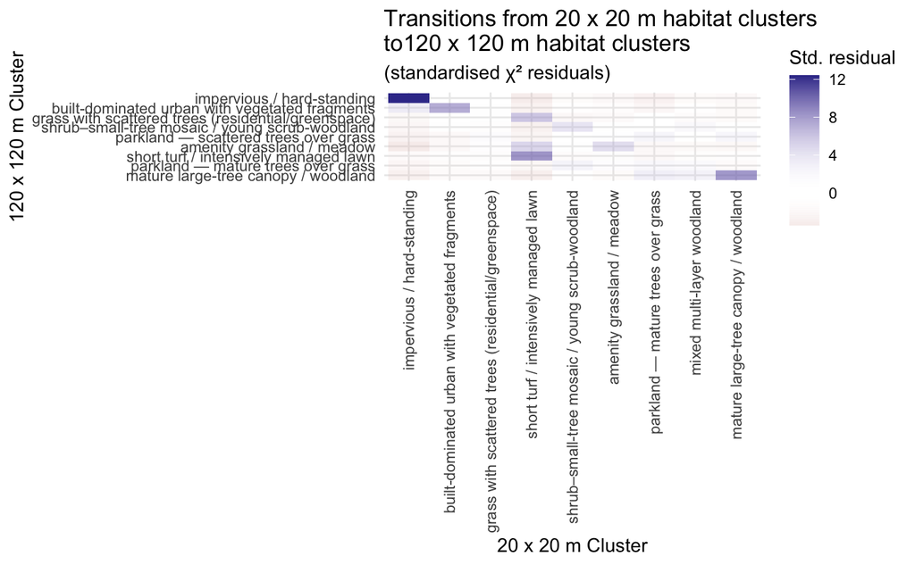

## Per-cluster “stability”: who keeps vs loses plots?

Here you look at whether each named cluster is stable in identity for individual plots.

```
clusters =
  plots %>%
  mutate(
    same_cluster = insect_plants_cluster_name == birds_cluster_name   # TRUE/FALSE per plot
  )
```

```
stab_by_cluster =
  clusters %>%
  group_by(insect_plants_cluster_name) %>%
  summarise(
    n_plots = n(),
    n_same  = sum(same_cluster),
    p_same  = n_same / n_plots
  )

stab_by_cluster
```

| insect_plants_cluster_name | n_plots | n_same | p_same |
| --- | --- | --- | --- |
| amenity grassland / meadow | 38 | 15 | 0.3947368 |
| built-dominated urban with vegetated fragments | 20 | 12 | 0.6000000 |
| grass with scattered trees (residential/greenspace) | 40 | 6 | 0.1500000 |
| impervious / hard-standing | 58 | 38 | 0.6551724 |
| mature large-tree canopy / woodland | 22 | 14 | 0.6363636 |
| mixed multi-layer woodland | 30 | 0 | 0.0000000 |
| parkland — mature trees over grass | 76 | 13 | 0.1710526 |
| short turf / intensively managed lawn | 80 | 16 | 0.2000000 |
| shrub–small-tree mosaic / young scrub-woodland | 47 | 12 | 0.2553191 |

That gives you:

Retention rate p_same per 20x20 habitat class: proportion of plots that are still in that same habitat label at 120x120

You can add binomial CIs:

```
stab_by_cluster =
  stab_by_cluster %>%
  rowwise() %>%
  mutate(
    lower = binom.test(n_same, n_plots)$conf.int[1],
    upper = binom.test(n_same, n_plots)$conf.int[2]
  ) %>%
  ungroup()
stab_by_cluster
```

| insect_plants_cluster_name | n_plots | n_same | p_same | lower | upper |
| --- | --- | --- | --- | --- | --- |
| amenity grassland / meadow | 38 | 15 | 0.3947368 | 0.24038789 | 0.5661385 |
| built-dominated urban with vegetated fragments | 20 | 12 | 0.6000000 | 0.36054259 | 0.8088099 |
| grass with scattered trees (residential/greenspace) | 40 | 6 | 0.1500000 | 0.05710226 | 0.2983527 |
| impervious / hard-standing | 58 | 38 | 0.6551724 | 0.51880268 | 0.7750991 |
| mature large-tree canopy / woodland | 22 | 14 | 0.6363636 | 0.40657667 | 0.8280206 |
| mixed multi-layer woodland | 30 | 0 | 0.0000000 | 0.00000000 | 0.1157033 |
| parkland — mature trees over grass | 76 | 13 | 0.1710526 | 0.09434516 | 0.2747266 |
| short turf / intensively managed lawn | 80 | 16 | 0.2000000 | 0.11885909 | 0.3043689 |
| shrub–small-tree mosaic / young scrub-woodland | 47 | 12 | 0.2553191 | 0.13944912 | 0.4034952 |

```
ggplot(stab_by_cluster, aes(x = insect_plants_cluster_name, y = p_same)) +
  geom_pointrange(aes(ymin = lower, ymax = upper)) +
  coord_flip() +
  labs(x = "20 x 20 m Cluster", y = "Proportion of plots with same cluster at 120 x 120 m") +
  theme_minimal()
```

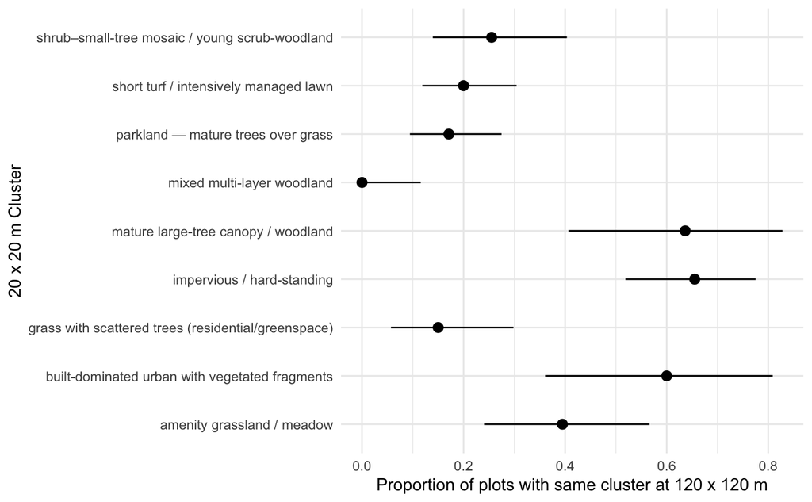